# Exercise 6: Longitudinal data

```r
library(MASS)
library(tidyverse)
library(ggplot2)
library(corrplot)
library(knitr)
library(GGally)
library(FactoMineR)
library(lme4)
library(gridExtra)
library(lemon)
```

The data wrangling script can be found [here](https://github.com/jonathanholder/IODS-project/blob/master/data/meet_and_repeat.R), including some notes on the data format.

Read data, factorise again (gets lost in I/O):

```r
rats.l <- read.csv("data/rats.l.csv")
bp.l <- read.csv("data/bprs.l.csv")
# factorise again, has been lost in re-reading
rats.l$ID <- as.factor(rats.l$ID)
rats.l$Group <- as.factor(rats.l$Group)

bp.l$treatment <- as.factor(bp.l$treatment)
bp.l$subject <- as.factor(bp.l$subject)
```

# 1: RATS

## Visualising individual data

```r
head(rats.l)
```

```
##   X ID Group time weight
## 1 1  1     1    1    240
## 2 2  2     1    1    225
## 3 3  3     1    1    245
## 4 4  4     1    1    260
## 5 5  5     1    1    255
## 6 6  6     1    1    260
```

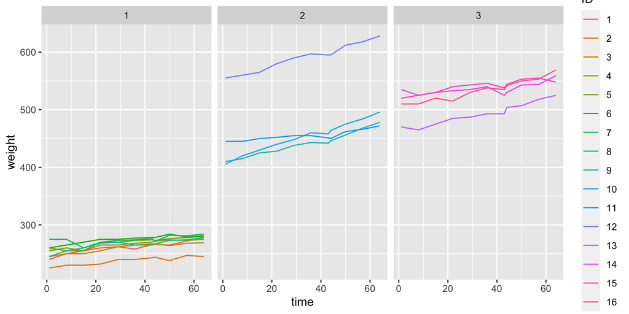

```r
# plot original weights, col = ID, facet = group
ggplot(rats.l, aes(x = time, y = weight, col = ID)) +
  geom_line()+
  facet_grid(. ~ Group)
```

In the above plot, it becomes clear that the weight of the individual rats differ clearly between group 1 and groups 2 and 3. The rats in group 1 have considerably lower starting weights, and it looks like their weight is rather constant during the study period compared to the other groups. both group 2 and 3 show a clear trend in weight increase. The variance in group 2 is comparatively high, owing to the high starting weight of individual 12. The weight of rats seems to be higher in group 3 than in group 2 (leaving aside individual 12).

One way to examine the development of the variable of interest over time is to look at the tracking effect by standardising the data, i.e. to check if the differences between the individual weight developments / final weights is merely an effect of different starting values (weights).

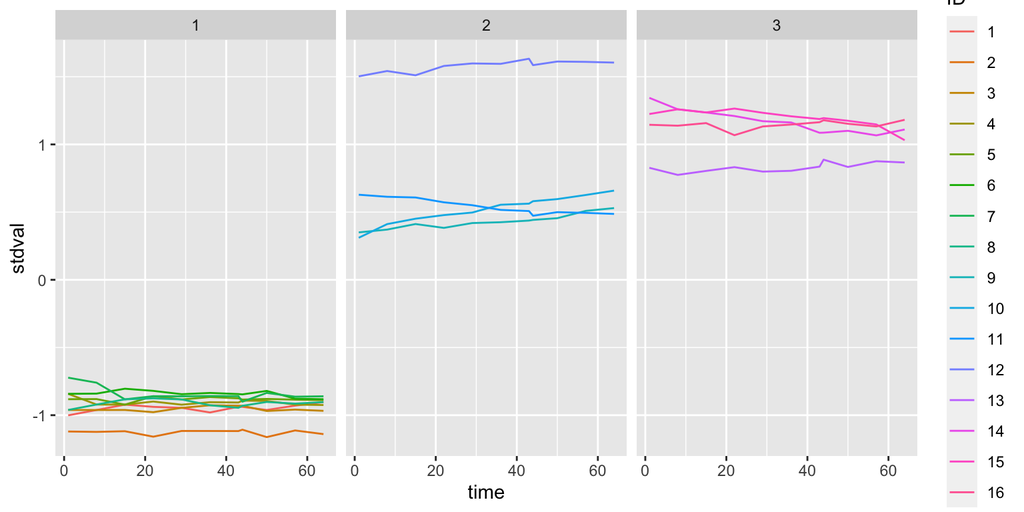

```r
rats.l <- rats.l %>%
  group_by(time) %>%
  mutate(stdval = (weight - mean(weight))/sd(weight) ) %>%
  ungroup()

ggplot(rats.l, aes(x = time, y = stdval, col = ID)) +
  geom_line()+
  facet_grid(. ~ Group)
```

The above plot suggests that indeed the starting weight is of major importance for the weight development.

# Summary measures

In the case of the rats dataset with just 16 individuals, plotting each subject individually is still interpretable, but larger datasets often require summary measures, e.g. the mean and its standard error of the individuals at each time step, so here’s a plot of the group means and the corresponding standard errors (as error bars):

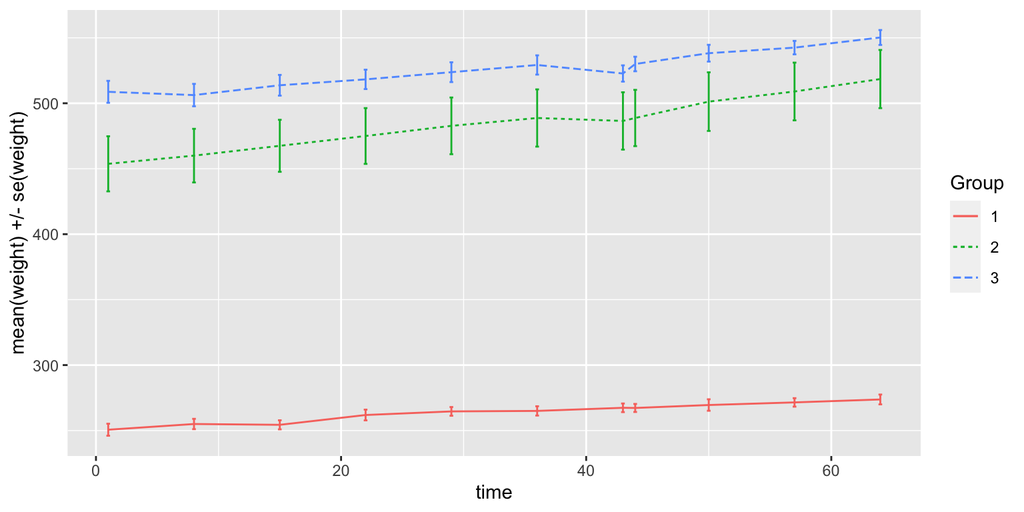

```r
rats.sum <- rats.l %>%
  group_by(Group, time) %>%
  summarise( mean = mean(weight), se = sd(weight)/sqrt(length(unique(rats.l$time)))) %>%
  ungroup()


ggplot(rats.sum, aes(x = time, y = mean, linetype = Group, shape = Group, col=Group)) +
  geom_line() +
  geom_errorbar(aes(ymin=mean-se, ymax=mean+se, linetype="1"), width=0.3) +
  scale_y_continuous(name = "mean(weight) +/- se(weight)")
```

The mean weights at the start of the study clearly differ between the groups; there is less difference between the weight increment over time between groups, but group 1 still seems to gain about half as much weight in absolute terms as groups 2 and 3 (though the relative weight increment over time could be similar). Note the larger standard error of group 2 (can largely be ascribed to the heavy individual 12).

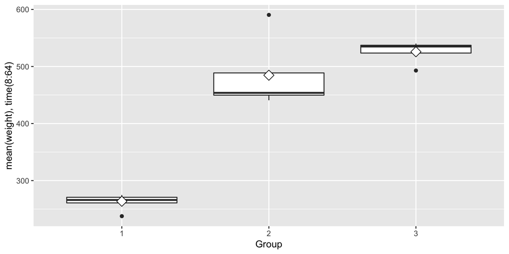

```r
rats.sum2 <- rats.l %>%
  filter(time > 0) %>%
  group_by(Group, ID) %>%
  summarise( mean=mean(weight) ) %>%
  ungroup()


ggplot(rats.sum2, aes(x = Group, y = mean)) +
  geom_boxplot() +
  stat_summary(fun.y = "mean", geom = "point", shape=23, size=4, fill = "white") +
  scale_y_continuous(name = "mean(weight), time(8:64)")
```

# T-tests & ANOVA

One option to check if the groups (however they have been treated) are significantly different from one another is a two-sample t-test (here applied to all three group combinations):

```r
t.test(mean ~ Group, data = rats.sum2[rats.sum2$Group%in%c(1,2),], var.equal = TRUE)
```

```
##
##  Two Sample t-test
##
## data:  mean by Group
## t = -9.0193, df = 10, p-value = 4.059e-06
## alternative hypothesis: true difference in means is not equal to 0
## 95 percent confidence interval:
##  -275.5817 -166.3956
## sample estimates:
## mean in group 1 mean in group 2
##        263.7159        484.7045
```

```r
t.test(mean ~ Group, data = rats.sum2[rats.sum2$Group%in%c(1,3),], var.equal = TRUE)
```

```
##
##  Two Sample t-test
##
## data:  mean by Group
## t = -27.361, df = 10, p-value = 9.848e-11
## alternative hypothesis: true difference in means is not equal to 0
## 95 percent confidence interval:
##  -283.4218 -240.7373
## sample estimates:
## mean in group 1 mean in group 3
##        263.7159        525.7955
```

```r
t.test(mean ~ Group, data = rats.sum2[rats.sum2$Group%in%c(2,3),], var.equal = TRUE)
```

```
##
##  Two Sample t-test
##
## data:  mean by Group
## t = -1.1086, df = 6, p-value = 0.3101
## alternative hypothesis: true difference in means is not equal to 0
## 95 percent confidence interval:
##  -131.79027   49.60845
## sample estimates:
## mean in group 2 mean in group 3
##        484.7045        525.7955
```

As expected suggest the outputs that group 1 is significantly different from both group 2 and group 3, but groups 2 and 3 are not significantly different from each other. This is probably an effect of the heavy individual in group 2 (ID=12) which impacts the group 2 variance, which covers the whole variance of group 3. I wouldn’t be comfortable to consider ID12 an outlier, let alone excluding it from the analysis, as the group only consists of 4 individuals, and the weight gain seems reasonable compared to others - it just seems to be a heavy fellow from the beginning on, judging from the available data (time span).

Below you find an ANOVA of a linear model including both group and the starting weight (retrieved from the original dataset in wide format):

```r
rats <- read.table("https://raw.githubusercontent.com/KimmoVehkalahti/MABS/master/Examples/data/rats.txt", header=T)
rats.sum2$startw <-  rats$WD1
anova(lm(mean~startw+Group, data=rats.sum2))
```

```
## Analysis of Variance Table
##
## Response: mean
##           Df Sum Sq Mean Sq   F value    Pr(>F)
## startw     1 252125  252125 2237.0655 5.217e-15 ***
## Group      2    726     363    3.2219   0.07586 .
## Residuals 12   1352     113
## ---
## Signif. codes:  0 '***' 0.001 '**' 0.01 '*' 0.05 '.' 0.1 ' ' 1
```

– the weight at the start of the measurement period explains considerably more variance than the group treatments (though the differences between groups are not further divided here…)

# 2: BPRS

## Plotting measured data

Plotting the bprs values over time for each individual separately:

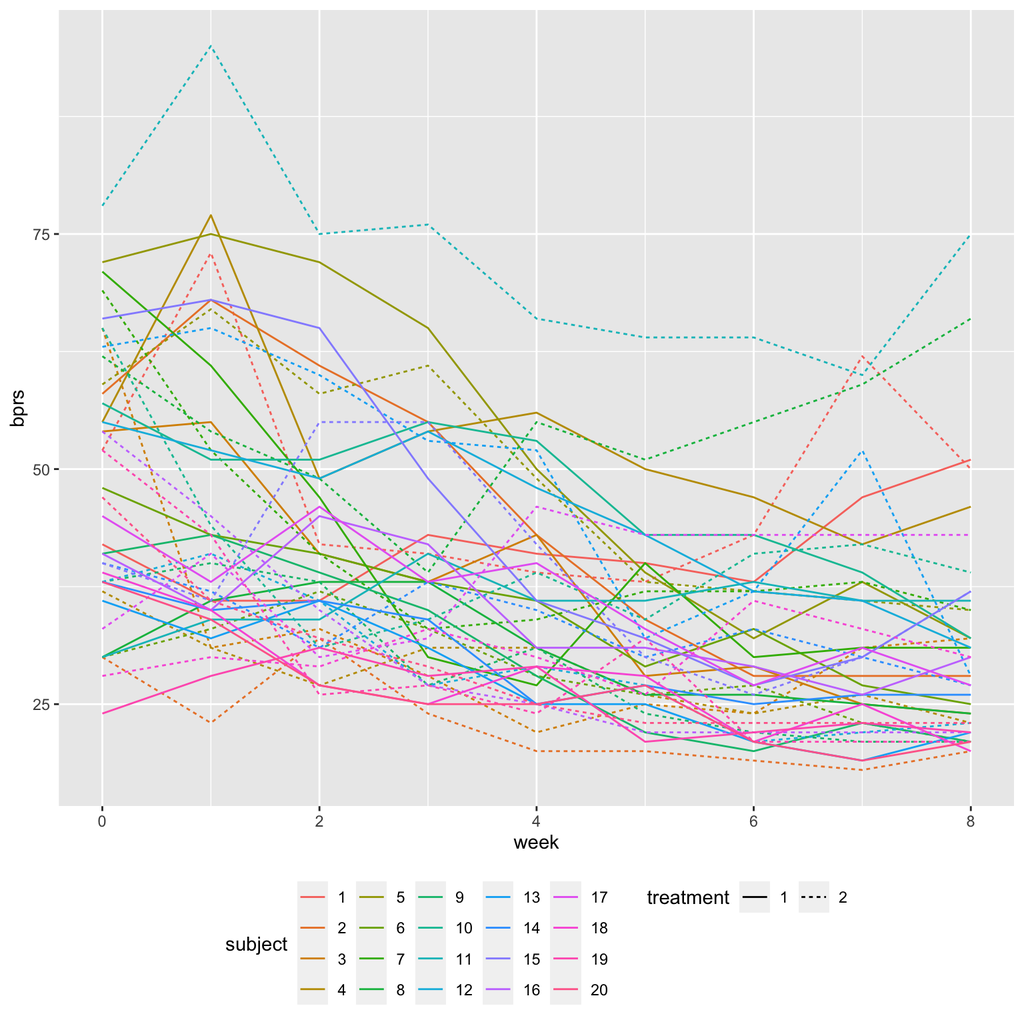

```r
ggplot(bp.l, aes(x = week, y = bprs, col = subject, lty = treatment)) +
  geom_line()+
  # scale_x_continuous(name = "Time (days)", breaks = seq(0, 60, 10))+
  # scale_y_continuous(name = "Weight (grams)")+
   theme(legend.position = "bottom")
```

– as mentioned before, just plotting the dynamics of a variable per individual can be confusing with larger datasets (and ones with high temporal fluctuations). It looks like the bprs score decreases for most individuals over time, but there’s not much more to be easily read from this plot.

## Regression model

A simple regression model with bprs as a function of time (week) and treatment suggests that time has a significant (negative) effect on the bprs score, while treatment does not have a significant impact:

```r
bp_reg <- lm(bprs~week + treatment, data=bp.l)
summary(bp_reg)
```

```
##
## Call:
## lm(formula = bprs ~ week + treatment, data = bp.l)
##
## Residuals:
##     Min      1Q  Median      3Q     Max
## -22.454  -8.965  -3.196   7.002  50.244
##
## Coefficients:
##             Estimate Std. Error t value Pr(>|t|)
## (Intercept)  46.4539     1.3670  33.982   <2e-16 ***
## week         -2.2704     0.2524  -8.995   <2e-16 ***
## treatment2    0.5722     1.3034   0.439    0.661
## ---
## Signif. codes:  0 '***' 0.001 '**' 0.01 '*' 0.05 '.' 0.1 ' ' 1
##
## Residual standard error: 12.37 on 357 degrees of freedom
## Multiple R-squared:  0.1851, Adjusted R-squared:  0.1806
## F-statistic: 40.55 on 2 and 357 DF,  p-value: < 2.2e-16
```

## Random intercept models

A similar model to the one above, but one that considers different intercepts for each subject may be helpful here, as it consideres the different ‘starting values’ of the bprs score of individuals between treatments.

```r
# random intercept model
bp_ref <- lmer(bprs ~ week + treatment + (1 | subject), data = bp.l, REML = FALSE)

# Print the summary of the model
summary(bp_ref)
```

```
## Linear mixed model fit by maximum likelihood  ['lmerMod']
## Formula: bprs ~ week + treatment + (1 | subject)
##    Data: bp.l
##
##      AIC      BIC   logLik deviance df.resid
##   2748.7   2768.1  -1369.4   2738.7      355
##
## Scaled residuals:
##     Min      1Q  Median      3Q     Max
## -3.0481 -0.6749 -0.1361  0.4813  3.4855
##
## Random effects:
##  Groups   Name        Variance Std.Dev.
##  subject  (Intercept)  47.41    6.885
##  Residual             104.21   10.208
## Number of obs: 360, groups:  subject, 20
##
## Fixed effects:
##             Estimate Std. Error t value
## (Intercept)  46.4539     1.9090  24.334
## week         -2.2704     0.2084 -10.896
## treatment2    0.5722     1.0761   0.532
##
## Correlation of Fixed Effects:
##            (Intr) week
## week       -0.437
## treatment2 -0.282  0.000
```

The random intercept model above, where subject has been included as a random effect, suggests that a substantial part of the variance in the intercept can be ascribed to the subjects.

Now let’s add week, i.e. the slope of the regression, as a random effect, considering both the intercept and the slope of individuals:

```r
bp_ref2 <- lmer(bprs ~ week + treatment + (week | subject), data = bp.l, REML = FALSE)
summary(bp_ref2)
```

```
## Linear mixed model fit by maximum likelihood  ['lmerMod']
## Formula: bprs ~ week + treatment + (week | subject)
##    Data: bp.l
##
##      AIC      BIC   logLik deviance df.resid
##   2745.4   2772.6  -1365.7   2731.4      353
##
## Scaled residuals:
##     Min      1Q  Median      3Q     Max
## -2.8919 -0.6194 -0.0691  0.5531  3.7977
##
## Random effects:
##  Groups   Name        Variance Std.Dev. Corr
##  subject  (Intercept) 64.8222  8.0512
##           week         0.9609  0.9803   -0.51
##  Residual             97.4304  9.8707
## Number of obs: 360, groups:  subject, 20
##
## Fixed effects:
##             Estimate Std. Error t value
## (Intercept)  46.4539     2.1052  22.066
## week         -2.2704     0.2977  -7.626
## treatment2    0.5722     1.0405   0.550
##
## Correlation of Fixed Effects:
##            (Intr) week
## week       -0.582
## treatment2 -0.247  0.000
```

```r
anova(bp_ref, bp_ref2)
```

```
## Data: bp.l
## Models:
## bp_ref: bprs ~ week + treatment + (1 | subject)
## bp_ref2: bprs ~ week + treatment + (week | subject)
##         Df    AIC    BIC  logLik deviance  Chisq Chi Df Pr(>Chisq)
## bp_ref   5 2748.7 2768.1 -1369.4   2738.7
## bp_ref2  7 2745.4 2772.6 -1365.7   2731.4 7.2721      2    0.02636 *
## ---
## Signif. codes:  0 '***' 0.001 '**' 0.01 '*' 0.05 '.' 0.1 ' ' 1
```

As the anova suggests, the random intercept and random slope model explains significantly more variance than the model with only random intercept.

## Random intercept model with interaction

As a last step, let’s include an interaction between treatment and time (probably the main interest of this study):

```r
bp_ref3 <- lmer(bprs ~ week * treatment + (week | subject), data = bp.l, REML = FALSE)
summary(bp_ref3)
```

```
## Linear mixed model fit by maximum likelihood  ['lmerMod']
## Formula: bprs ~ week * treatment + (week | subject)
##    Data: bp.l
##
##      AIC      BIC   logLik deviance df.resid
##   2744.3   2775.4  -1364.1   2728.3      352
##
## Scaled residuals:
##     Min      1Q  Median      3Q     Max
## -3.0512 -0.6271 -0.0768  0.5288  3.9260
##
## Random effects:
##  Groups   Name        Variance Std.Dev. Corr
##  subject  (Intercept) 64.9964  8.0620
##           week         0.9687  0.9842   -0.51
##  Residual             96.4707  9.8220
## Number of obs: 360, groups:  subject, 20
##
## Fixed effects:
##                 Estimate Std. Error t value
## (Intercept)      47.8856     2.2521  21.262
## week             -2.6283     0.3589  -7.323
## treatment2       -2.2911     1.9090  -1.200
## week:treatment2   0.7158     0.4010   1.785
##
## Correlation of Fixed Effects:
##             (Intr) week   trtmn2
## week        -0.650
## treatment2  -0.424  0.469
## wek:trtmnt2  0.356 -0.559 -0.840
```

```r
anova(bp_ref2, bp_ref3)
```

```
## Data: bp.l
## Models:
## bp_ref2: bprs ~ week + treatment + (week | subject)
## bp_ref3: bprs ~ week * treatment + (week | subject)
##         Df    AIC    BIC  logLik deviance  Chisq Chi Df Pr(>Chisq)
## bp_ref2  7 2745.4 2772.6 -1365.7   2731.4
## bp_ref3  8 2744.3 2775.4 -1364.1   2728.3 3.1712      1    0.07495 .
## ---
## Signif. codes:  0 '***' 0.001 '**' 0.01 '*' 0.05 '.' 0.1 ' ' 1
```

The model performs with the interaction performs slightly better, but, according to the Chi Square test, this improvement is not significant.

So here’s again the initial plot of all bprs scores of individuals over time and plots of the the predictions of the two latest models (lme with and without interaction between week and treatment):

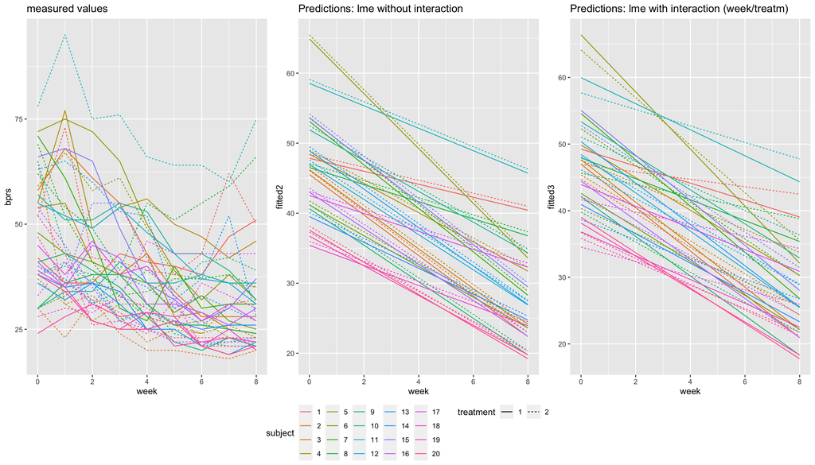

```r
p_base <- ggplot(bp.l, aes(x = week, y = bprs, col = subject, lty = treatment)) +
  geom_line()+
  ggtitle("measured values")+
   theme(legend.position = "bottom")

# add fitted values
bp.l$fitted2 <- fitted(bp_ref2)# model without intetraction
bp.l$fitted3 <- fitted(bp_ref3)# model with interaction

# plot predictions
p_m2 <- ggplot(bp.l, aes(x = week, y = fitted2, col = subject, lty = treatment)) +
  geom_line()+
  theme(legend.position = "bottom")+
  ggtitle("Predictions: lme without interaction")
p_m3 <- ggplot(bp.l, aes(x = week, y = fitted3, col = subject, lty = treatment)) +
  geom_line()+
  theme(legend.position = "bottom")+
  ggtitle("Predictions: lme with interaction (week/treatm)")
grid_arrange_shared_legend(p_base, p_m2, p_m3, nrow=1)
```

The models predict an overall decreasing trend of the bprs scores, differentiating both slope (speed of change) and intercept (‘starting score’) between individuals. Note that the effect of including the interaction between week and treatment leads to slight differences in the predictions for an individual between treatments over time (slope) compared to the model without interactions, as well as slight differences in intercepts.